# rna-seq-composition

Holly Beale

Mon Aug 17 08:18:19 PM 2020

```r
library(tidyverse)
library(gridExtra)
library(grid)

library(EnvStats)
library(janitor)
library(patchwork)

library(knitr)
```

```r
data_dir <- file.path("..", "..", "data")
scratch_dir <- file.path("..", "..", "scratch", "rna-seq-composition")

results_dir <- "results"
plots_dir <- "plots"

lapply(c(results_dir, plots_dir, scratch_dir), function(output_dir){
# Create output dirs if they do not exist
if (!dir.exists(output_dir)) {
  dir.create(output_dir, recursive = TRUE)
}
})
```

```
## [[1]]
## NULL
##
## [[2]]
## NULL
##
## [[3]]
## [1] TRUE
```

# Extract tar files

```r
lapply(file.path(data_dir, c("pbta-mend-qc-results.tar.gz", "pbta-star-log-final.tar.gz")),
       untar,
       exdir = file.path(scratch_dir))
```

```
## [[1]]
## [1] 0
##
## [[2]]
## [1] 0
```

# Import MEND data

```r
mend_results_cols <- cols(
  input = col_character(),
  uniqMappedNonDupeReadCount = col_double(),
  estExonicUniqMappedNonDupeReadCount = col_double(),
  qc = col_character()
)

read_count_results_cols <- cols(
  n1 = col_character(),
  n2 = col_character(),
  read_counts = col_double()
)

# MEND results
mend_results <- tibble(MEND_results_file = list.files(scratch_dir, "bam_umend_qc.tsv")) %>%
  mutate(mnd_and_mend = map(file.path(scratch_dir, MEND_results_file), read_tsv, col_types = mend_results_cols)) %>%
  unnest(mnd_and_mend) %>%
  rename(MND = uniqMappedNonDupeReadCount ,
         MEND = estExonicUniqMappedNonDupeReadCount) %>%
  select(-input)

head(mend_results)
```

```
## # A tibble: 6 x 4
##   MEND_results_file                                      MND     MEND qc
##   <chr>                                                <dbl>    <dbl> <chr>
## 1 004383d0-9f9f-431d-8684-288805a86e37.bam_umend_… 41028647    3.07e7 PASS
## 2 006835f8-8268-4e3d-97f8-67ca83761d4c.bam_umend_… 65839424.   5.09e7 PASS
## 3 00cbefa4-e79c-47cb-831d-de48268b14e1.bam_umend_… 66999896.   5.80e7 PASS
## 4 00df43b3-15e5-4975-81af-cb775d663cc7.bam_umend_… 79563822.   5.66e7 PASS
## 5 0231e385-162c-43d0-8c7d-882d1ea8a7ef.bam_umend_… 89711570    6.78e7 PASS
## 6 026e8027-c2c6-4845-8afc-226a34fd8f87.bam_umend_… 64017591    4.88e7 PASS
```

# Import STAR data

```r
read_measurement_names <-
  tibble(orig_col_name = c("Number of input reads",
                           "Uniquely mapped reads number",
                           "Number of reads mapped to multiple loci"),
         short_name = c("Total_reads", "UniqMapped_reads", "Multimapped"))

parse_star_log <- function(file_name) {
  tibble(raw=scan(file_name, what = "list", sep ="\n",  quiet = TRUE)) %>%
    filter(grepl(paste(read_measurement_names$orig_col_name,collapse="|"), raw)) %>%
    mutate(measurement_name = gsub(" \\|\t.*$", "", raw),
           measurement_value = as.numeric(gsub("^.*\t", "", raw)),
           star_results_file = gsub(paste0(scratch_dir, "/"), "", file_name),
           measurement_name = str_trim(measurement_name)) %>%
    select(-raw)
}

# STAR results
star_results <- file.path(scratch_dir, list.files(scratch_dir, ".Log.final.out")) %>%
  lapply(parse_star_log) %>%
  bind_rows %>%
  left_join(read_measurement_names, by=c("measurement_name"="orig_col_name")) %>%
  select(-measurement_name) %>%
  spread(key=short_name, value = measurement_value)


head(star_results)
```

```
## # A tibble: 6 x 4
##   star_results_file                Multimapped Total_reads UniqMapped_reads
##   <chr>                                  <dbl>       <dbl>            <dbl>
## 1 00245bb9-b207-4648-b26e-bf16ec3…    18434551   110290003         88689347
## 2 0071cbef-6d2d-4328-b95b-f1076b6…    12634273   123649499        108812782
## 3 0080e250-aef6-4501-8f0e-42b4832…    13592442    92071962         77367447
## 4 00a72866-565d-4e01-a666-e13ea72…    13275735   115052589        100098378
## 5 00d202e7-8c8b-4696-9d4b-8221e62…    17686325   103572132         83713766
## 6 00d8fca5-287f-40bb-a2bc-56bfd41…     9792571    86877531         74507278
```

# Combine data by sample

```r
# Import manifest info required to combine results from different outputs
pbta_mend_qc_manifest <- read_tsv(
  file.path(data_dir, "pbta-mend-qc-manifest.tsv"),
  col_types = cols(.default = col_character()))

pbta_star_log_manifest <- read_tsv(file.path(data_dir,"pbta-star-log-manifest.tsv"),
                                  col_types = cols(.default = col_character())) %>%
  mutate(Sample = gsub(".Log.final.out", "", name))

star_results_w_biospec <- left_join(star_results, pbta_star_log_manifest, by=c("star_results_file"="name"))

mend_results_w_biospec <- left_join(mend_results, pbta_mend_qc_manifest, by=c("MEND_results_file"="name"))

# Confirm that all samples are present in both
stopifnot(all(star_results_w_biospec$Kids.First.Biospecimen.ID %in% mend_results_w_biospec$Kids.First.Biospecimen.ID))

# Combine results from different outputs
comb_results <- full_join(star_results_w_biospec,
                          mend_results_w_biospec,
                          by="Kids.First.Biospecimen.ID") %>%
  select(-star_results_file, -MEND_results_file, -qc, -Sample) %>%
  rename(sample_id = Kids.First.Biospecimen.ID)
```

# Groom data

```r
read_counts <- comb_results %>%
  mutate(Mapped = Multimapped + UniqMapped_reads) %>%
  select(-UniqMapped_reads)
```

# Filter for library prep method

```r
metadata_raw <- read_tsv(file.path(data_dir, "pbta-histologies.tsv"),
                          guess_max = 10000)
metadata <- metadata_raw %>%
  filter(experimental_strategy == "RNA-Seq") %>%
  select(Kids_First_Biospecimen_ID, RNA_library, composition, sample_type)

# How many samples of each type are present?
metadata %>% tabyl(RNA_library, composition, sample_type)
```

```
## $Tumor
##  RNA_library Derived Cell Line Solid Tissue
##       poly-A                 0           58
##     stranded                16          954
```

```r
stranded_samples <- metadata %>%
  filter(RNA_library == "stranded") %>%
  pull(Kids_First_Biospecimen_ID)

selected_read_counts <- read_counts %>%
  filter(sample_id %in% stranded_samples)
```

This analysis is performed only on ribo-deplete data (stranded). Data from cell lines and solid tissues are both included.

# Calculate fractions of each read type

```r
read_counts_with_read_type_fractions <- selected_read_counts %>%
  arrange(desc(Total_reads)) %>%
  mutate(frac_unmapped_of_total = (Total_reads - Mapped)/Total_reads,
         frac_multi_mapped_of_mapped = Multimapped/Mapped, # Mapped = UM + MM
         frac_dupe_of_mapped = (Mapped - MND) / Mapped,
         frac_non_exonic_of_non_dupe = (MND - MEND)/MND)

read_type_fractions_long <- read_counts_with_read_type_fractions %>%
  select(c(sample_id, starts_with("frac_"))) %>%
  gather(key="read_type_name", value = "value", -sample_id)
```

# Calculate reference ranges

```r
read_type_codes <- as_tibble(
  list(read_type_abbrev = c("NM", "MM", "D", "NE"),
       read_type_description =
         c("Not mapped", "Multi-mapped", "Duplicate reads", "Non exonic reads"),
       read_type_name =
         c("frac_unmapped_of_total", "frac_multi_mapped_of_mapped",
           "frac_dupe_of_mapped", "frac_non_exonic_of_non_dupe"
         )))

# Calculate summary statistics for each read type (wide)
read_type_fraction_mean_sd <- read_counts_with_read_type_fractions %>%
  select(starts_with("frac_")) %>%
  gather(key="read_type_name") %>%
  group_by(read_type_name) %>%
  summarise(mean = mean(value),
            sd = sd(value),
            mean_minus_one_sd = mean - sd,
            mean_plus_one_sd = mean + sd,
            mean_minus_two_sd = mean - (2 * sd),
            mean_plus_two_sd = mean + (2 * sd)
  )

# Longify summary statistics and annoate for plotting
all_read_type_fraction_stats <- read_type_fraction_mean_sd %>%
  select(-sd) %>%
  gather(key="stat_name", value = "value", -read_type_name) %>%
  mutate(minmax = case_when(grepl("plus", stat_name) ~ "max",
                            grepl("minus", stat_name) ~ "min",
                            stat_name == "mean" ~ "mean"),
         stat = gsub("^.*_([[:lower:]]{3}_.*)", "\\1", stat_name),
         read_type_name = factor(read_type_name,
                                 levels = read_type_codes$read_type_name))
```

# Select reference ranges that will be used to flag samples

```r
read_type_frac_thresholds <- all_read_type_fraction_stats %>%
  filter(stat == "two_sd") %>%
  select(-stat, -stat_name) %>%
  spread(key = "minmax", value = "value") %>%
  rename(min_frac = min, max_frac = max)

kable(read_type_frac_thresholds)
```

| read_type_name | max_frac | min_frac |
| --- | --- | --- |
| frac_unmapped_of_total | 0.0411466 | 0.0020013 |
| frac_multi_mapped_of_mapped | 0.2167388 | 0.0572609 |
| frac_dupe_of_mapped | 0.5997126 | 0.2034031 |
| frac_non_exonic_of_non_dupe | 0.5145610 | 0.0824630 |

## Identify samples within reference range

```r
read_fracs_with_thresholds <- left_join(read_type_fractions_long, read_type_frac_thresholds, by = "read_type_name") %>%
  rename(sample_value = value) %>%
  mutate(within_limits = case_when(
      sample_value >= max_frac ~ "above_limit",
      sample_value <= min_frac ~ "below_limit",
      is.finite(sample_value) ~ "within_limits" ))
n_read_types <- n_distinct(read_type_frac_thresholds$read_type_name)

samples_within_limits <- read_fracs_with_thresholds %>%
  group_by(sample_id) %>%
  filter(sum(grepl("within_limits", within_limits)) == n_read_types) %>%
  pull(sample_id) %>% unique

mend_count_codes <- tibble(
  mend_count_label = c("<10M_MEND_reads", ">20M_MEND_reads", "10-20 MEND_reads"),
  mend_count_flag_abbrev = c("<10M", "", "10-20M"))

depth_status <- read_counts_with_read_type_fractions %>%
  select(sample_id, MEND) %>%
  mutate(
    status = case_when(MEND<10E6 ~ "<10M_MEND_reads",
                       MEND<20E6 ~ "10-20 MEND_reads",
                       is.finite(MEND) ~ ">20M_MEND_reads"),
    all_read_types_within_read_type_limits = sample_id %in% samples_within_limits,
    within_read_type_limits_label = c( "not_WNL", "WNL")[1 + all_read_types_within_read_type_limits]
  ) %>%
  left_join(mend_count_codes, by=c("status"="mend_count_label"))

# How many read type fractions are outside ref range?
# (total = 4 * n(samples))
table(read_fracs_with_thresholds$within_limits)
```

```
##
##   above_limit   below_limit within_limits
##           162             5          3713
```

```r
# How many samples in each MEND depth group were outside ref range?
tabyl(depth_status, within_read_type_limits_label, status)
```

```
##  within_read_type_limits_label <10M_MEND_reads >20M_MEND_reads
##                        not_WNL               8              86
##                            WNL               0             849
##  10-20 MEND_reads
##                18
##                 9
```

```r
threshold_flag_annotations <- read_fracs_with_thresholds %>%
  left_join(read_type_codes, by="read_type_name") %>%
  mutate(threshold_code = ifelse(within_limits == "within_limits", NA, read_type_abbrev)) %>%
  group_by(sample_id) %>%
  summarize(flagged_thresholds = paste(na.omit(threshold_code), collapse=", "))

read_fracs_with_thresholds <- read_fracs_with_thresholds %>%
  left_join(threshold_flag_annotations, by="sample_id")
```

# Prepare data for summary plot

## Specify labels and levels

```r
stat_names = c("frac_unmapped_of_total", "frac_multi_mapped_of_mapped", "frac_dupe_of_mapped", "frac_non_exonic_of_non_dupe")
stat_label = c("frac unmapped", "frac multi-mapped \n(of mapped)", "frac duplicate \n(of mapped)", "frac non-exonic \n(of non-duplicate)")
names(stat_label) = stat_names


limit_status_levels <- c("below_limit", "within_limits", "above_limit")
limit_status_colors <- c("white", "grey", "black")
names(limit_status_colors) <- limit_status_levels

MEND_depth_codes <- c("<10M_MEND_reads", "10-20 MEND_reads", ">20M_MEND_reads")
MEND_depth_colors <- c("red", "pink", "springgreen4")
names(MEND_depth_colors) <- MEND_depth_codes

limit_and_MEND_vec <- c(limit_status_colors, MEND_depth_colors)
```

## Add factors and prepare text

```r
read_fracs_with_thresholds_anno <- read_fracs_with_thresholds %>%
  mutate(read_type_name = factor(read_type_name, levels = read_type_codes$read_type_name),
         within_limits = factor(within_limits, levels = limit_status_levels))
```

## Tabulate excluded samples

```r
flag_summary_stats <- read_fracs_with_thresholds_anno  %>%
  mutate(`Fraction of sample` = gsub("\n", "", stat_label[match(read_type_name, names(stat_label))])) %>%
  #  group_by(read_type_name) %>%
  tabyl(`Fraction of sample`, within_limits) %>%
  adorn_totals(where = c("col")) %>%
  adorn_percentages(denominator = "row") %>%
  adorn_pct_formatting(digits = 0) %>%
  adorn_ns() %>%
  mutate(`Fraction of sample` = factor(`Fraction of sample`,
                                       levels = gsub("\n", "", stat_label))) %>%
  arrange(`Fraction of sample`)
```

## Histogram

```r
plot_title <- paste0(sum(threshold_flag_annotations$flagged_thresholds!=""), " samples are outside reference ranges")

p20 <-  ggplot(read_fracs_with_thresholds_anno) +
  geom_histogram(aes(x = sample_value, fill = read_type_name)) +
  geom_vline(data=all_read_type_fraction_stats,
             aes(xintercept = value, linetype = stat, color = read_type_name)) +
    scale_fill_viridis_d() +
  scale_color_viridis_d() +
  facet_wrap(~read_type_name,
             nrow=1,
             scales="free_x",
             labeller = labeller(read_type_name=stat_label) )

p20c <- p20 +
  theme(legend.position = "none") +
  ylab("Samples") +
  xlab(paste0("Relative sample composition, n=", length(unique(read_fracs_with_thresholds$sample_id)))) +
  ggtitle(plot_title)
```

# Generate summary plot

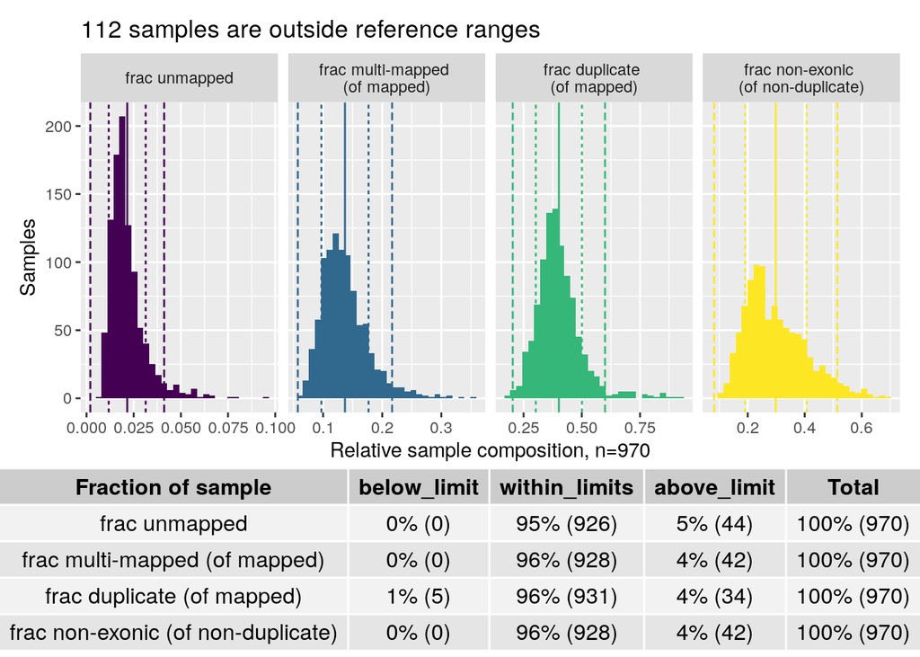

```r
tbl <- tableGrob(flag_summary_stats, rows=NULL)

wrap_plots(p20c, tbl, ncol=1, heights = 2:1)
```

```r
ggsave(file.path(plots_dir, "fractions_and_reference_ranges.png"), width = 8, height = 6)
```

# Export table of flagged samples

```r
# extract combined flag codes
sample_flag_codes <- read_fracs_with_thresholds_anno %>%
  select(sample_id, flagged_thresholds) %>%
  distinct

read_fracs_with_thresholds_anno %>%
  mutate(within_limits = gsub("within_limits", "", within_limits)) %>%
  select(sample_id, read_type_name, within_limits) %>%
  spread(key = "read_type_name", value = "within_limits") %>%
  left_join(depth_status %>% select(sample_id, status, mend_count_flag_abbrev)) %>%
  rename(MEND_depth_bin = status) %>%
  mutate(MEND_depth_bin = gsub(">20M_MEND_reads", "", MEND_depth_bin)) %>%
  left_join(sample_flag_codes, by="sample_id") %>%
  mutate(summary_flag_status = case_when(
    flagged_thresholds==mend_count_flag_abbrev ~ "not flagged", # they are equal if they are both blank
    flagged_thresholds=="" ~ mend_count_flag_abbrev,
    mend_count_flag_abbrev=="" ~ flagged_thresholds,
    TRUE ~ paste(flagged_thresholds, mend_count_flag_abbrev, sep = ", "))) %>%
  select(-mend_count_flag_abbrev, -flagged_thresholds) %>%
  write_tsv(file.path(results_dir, "samples_with_flags.tsv"))
```

# Visualize overlap in flags accrued per sample

```r
stat_names_plus_MEND <- c(stat_names, "MEND count")
stat_label_plus_MEND  <- c(stat_label, "MEND count range")


flag_analysis <- read_fracs_with_thresholds_anno %>%
  bind_rows(depth_status %>%
              mutate(read_type_name = "MEND count") %>%
              rename(within_limits=status)) %>%
  filter(! sample_id %in% samples_within_limits) %>%
  group_by(sample_id) %>%
  mutate(n_flags=sum(within_limits == "within_limits")) %>%
  arrange(desc(n_flags), flagged_thresholds) %>%
  ungroup() %>%
  mutate(sample_id = factor(sample_id, levels = unique(sample_id)),
         read_type_name = factor(read_type_name, levels = rev(stat_names_plus_MEND)) )
```

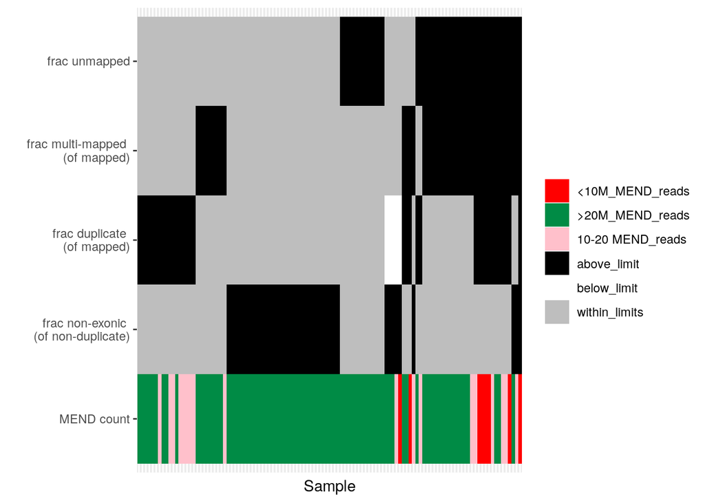

```r
ggplot(flag_analysis) +
  geom_tile(aes(x=sample_id, y=read_type_name, fill = within_limits)) +
   theme(axis.text.x = element_blank(), axis.ticks.x = element_blank()) +
  scale_y_discrete(breaks=stat_names_plus_MEND, labels=stat_label_plus_MEND) +
  scale_fill_manual("", values=limit_and_MEND_vec) +
  ylab("") + xlab("Sample")
```

Samples are ordered by the number of read fractions for which they exceed the reference range. Samples that exceed the range of non-exonic reads often only exceed that range and no other. Conversely, samples that exceed the unmapped threshold often also exceed the multi-mapper threshold; some of those samples also exceed the duplicate read threshold.

# Evaluate total and MEND read counts per read type and flag

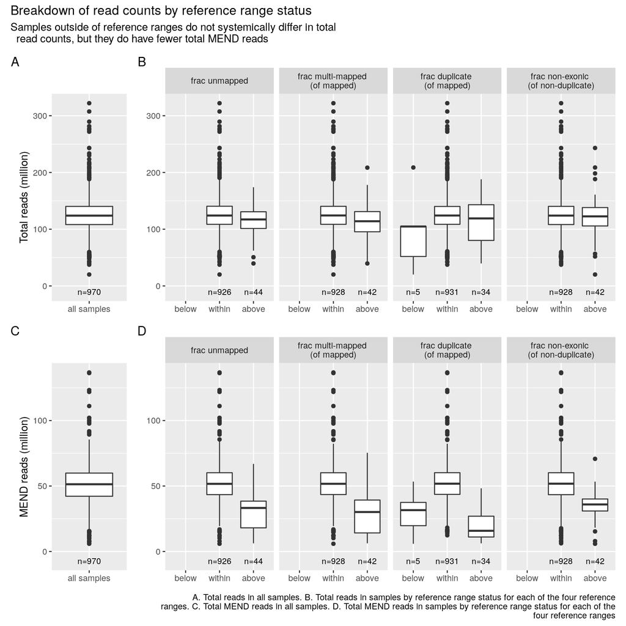

```r
samples_by_MEND <- read_fracs_with_thresholds_anno %>%
  left_join(read_counts_with_read_type_fractions %>%
              select(sample_id, MEND, Total_reads),
            by="sample_id")

p_total_reads_in_all <- ggplot(samples_by_MEND %>%
         select(sample_id, Total_reads) %>%
         distinct %>%
           mutate(value_name="all samples"),
         aes(y=Total_reads/1e6, x=value_name)
         ) +
  geom_boxplot() +
  EnvStats::stat_n_text(size=3) +
  theme(axis.title.x = element_blank()) +
  ylab("Total reads (million)")

p_MEND_reads_in_all <- ggplot(samples_by_MEND %>%
         select(sample_id, MEND) %>%
         distinct %>%
           mutate(value_name="all samples"),
         aes(y=MEND/1e6, x=value_name)
         ) +
  geom_boxplot() +
  EnvStats::stat_n_text(size=3) +
  theme(axis.title.x = element_blank()) +
  ylab("MEND reads (million)")

p_MEND_reads_by_read_type <-
  ggplot(samples_by_MEND, aes(x=within_limits, y=MEND/1e6)) +
  geom_boxplot() +
  EnvStats::stat_n_text(size=3) +
  scale_x_discrete(breaks=c("within_limits", "below_limit", "above_limit"),
                   labels = c("within", "below", "above")) +
  facet_wrap(~read_type_name, nrow=1, labeller = labeller(
    read_type_name=stat_label) ) +
  theme(axis.title = element_blank())

p_total_reads_by_read_type <-
  ggplot(samples_by_MEND, aes(x=within_limits, y=Total_reads/1e6)) +
  geom_boxplot() +
  EnvStats::stat_n_text(size=3) +
  scale_x_discrete(breaks=c("within_limits", "below_limit", "above_limit"),
                   labels = c("within", "below", "above")) +
  facet_wrap(~read_type_name, nrow=1, labeller = labeller(
    read_type_name=stat_label) ) +
  theme(axis.title = element_blank())

p_total_reads_in_all + p_total_reads_by_read_type +
  p_MEND_reads_in_all + p_MEND_reads_by_read_type +
  plot_layout(widths = c(1, 6)) +
  plot_annotation(
  title = "Breakdown of read counts by reference range status",
  subtitle = "Samples outside of reference ranges do not systemically differ in total
  read counts, but they do have fewer total MEND reads",
  caption = stringr::str_wrap('A. Total reads in all samples. B. Total reads in samples by reference range status for each of the four reference ranges. C. Total MEND reads in all samples. D. Total MEND reads in samples by reference range status for each of the four reference ranges', width = 120),
  tag_levels = 'A'
)
```

As seen in C and D, and by definition, samples that have high fractions of non-MEND reads have fewer MEND reads than other samples. However, they do not vary much from other samples in the number of total reads (A and B). In other words, the number of total reads does not determine whether a sample is at the extremes of the read type composition.

There are only five samples with unusually low duplicate reads fractions, limiting the conclusions that can be drawn.

# Number of measured genes

Here a measured gene is one with a non-zero TPM value.

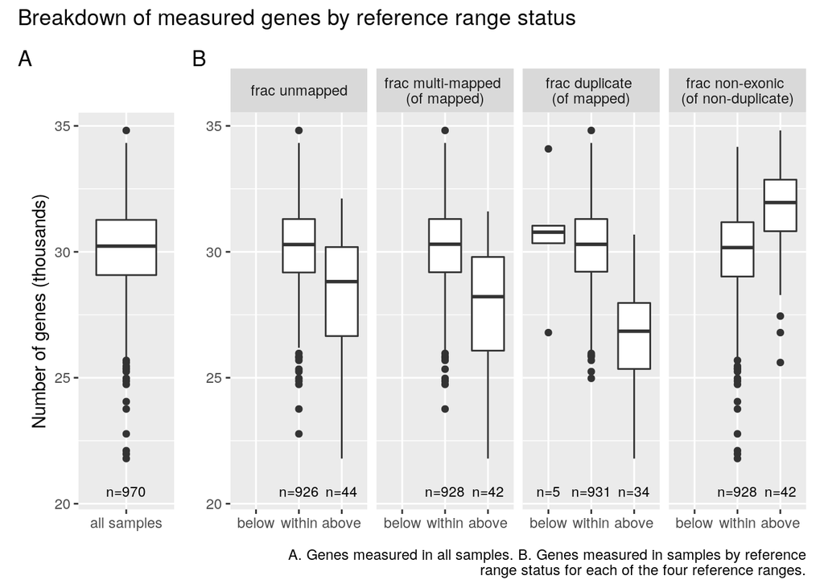

```r
expr <- readRDS(file.path(data_dir,"pbta-gene-expression-rsem-tpm.stranded.rds"))

genes_gt_zero <- apply(expr[,-1], 2, function(x) sum(x>0))

metadata_gene_counts <- metadata_raw %>%
  filter(RNA_library == "stranded",
         experimental_strategy == "RNA-Seq") %>%
  mutate(genes_gt_zero = genes_gt_zero[match(Kids_First_Biospecimen_ID, names(genes_gt_zero))]) %>%
  left_join(threshold_flag_annotations, by =c("Kids_First_Biospecimen_ID"="sample_id"))

read_fracs_with_thresholds_anno2 <- read_fracs_with_thresholds_anno %>%
  mutate(genes_gt_zero = genes_gt_zero[match(sample_id, names(genes_gt_zero))])

p_gene_counts_in_all <- ggplot(read_fracs_with_thresholds_anno2 %>%
         select(sample_id, genes_gt_zero) %>%
         distinct %>%
           mutate(value_name="all samples"),
         aes(y=genes_gt_zero/1e3, x=value_name)
         ) +
  geom_boxplot() +
  EnvStats::stat_n_text(size=3) +
  theme(axis.title.x = element_blank()) +
  ylab("Number of genes (thousands)")


p_gene_counts_by_read_type <- ggplot(read_fracs_with_thresholds_anno2, aes(x=within_limits, y=genes_gt_zero/1e3)) +
  geom_boxplot() +
  EnvStats::stat_n_text(size = 3) +
  scale_x_discrete(breaks=c("within_limits", "below_limit", "above_limit"),
                   labels = c("within", "below", "above")) +
  facet_wrap(~read_type_name, nrow=1, labeller = labeller(
    read_type_name=stat_label) ) +
  theme(axis.title = element_blank())


p_gene_counts_in_all + p_gene_counts_by_read_type +
  plot_layout(widths = c(1, 6)) +
  plot_annotation(
  title = "Breakdown of measured genes by reference range status",
  caption = stringr::str_wrap('A. Genes measured in all samples. B. Genes measured in samples by reference range status for each of the four reference ranges.', width = 80),
  tag_levels = 'A'
)
```

```r
ggsave(file.path(plots_dir, "Expressed_genes_by_status.png"), width = 8, height = 6)
```

Samples with extremely high unmapped, multi-mapped or duplicate read fractions generally measure fewer genes than their within-range counterparts. The reverse is true for samples with extremely high non-exonic read fractions. If the high number of non-exonic reads is due to genomic contamination, that genomic contamination might also result in apparent exonic reads from DNA from genes that are not producing RNA. In that scenario, the non-exonic reads would not be directly contributing to the higher gene count but would be another result of the phenomenon that also leads to a higher gene count.

There are only five samples with unusually low duplicate reads fractions, limiting the conclusions that can be drawn.